# EasyVisa Project

## Bagging Classifier

```python
#base_estimator for bagging classifier is a decision tree by default
bagging_estimator=BaggingClassifier(random_state=1)
bagging_estimator.fit(X_train,y_train)
```

```
BaggingClassifier(random_state=1)
```

```python
#Using above defined function to get accuracy, recall and precision on train and test set
bagging_estimator_score=get_metrics_score(bagging_estimator)
```

```
Accuracy on training set :  0.9802646333258578
Accuracy on test set :  0.7189952904238619
Recall on training set :  0.9466486577747762
Recall on test set :  0.44899566758566367
Precision on training set :  0.9936204146730463
Precision on test set :  0.6034939121228163
```

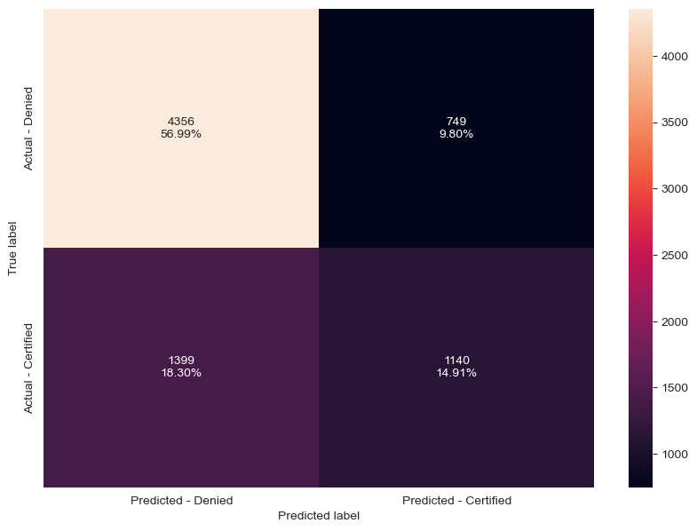

```python
# make confusion matrix
make_confusion_matrix(bagging_estimator,y_test)
```

### Random Forest Classifier

```python
#Train the random forest classifier
rf_estimator=RandomForestClassifier(random_state=1)
rf_estimator.fit(X_train,y_train)
```

```
RandomForestClassifier(random_state=1)
```

```python
#Using above defined function to get accuracy, recall and precision on train and test set
rf_estimator_score=get_metrics_score(rf_estimator)
```

```
Accuracy on training set :  1.0
Accuracy on test set :  0.7361329147043433
Recall on training set :  1.0
Recall on test set :  0.49389523434423
Precision on training set :  1.0
Precision on test set :  0.6314199395770392
```

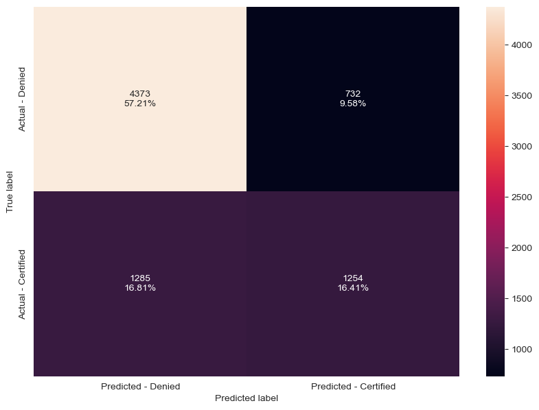

```python
# make confusion matrix
make_confusion_matrix(rf_estimator,y_test)
```

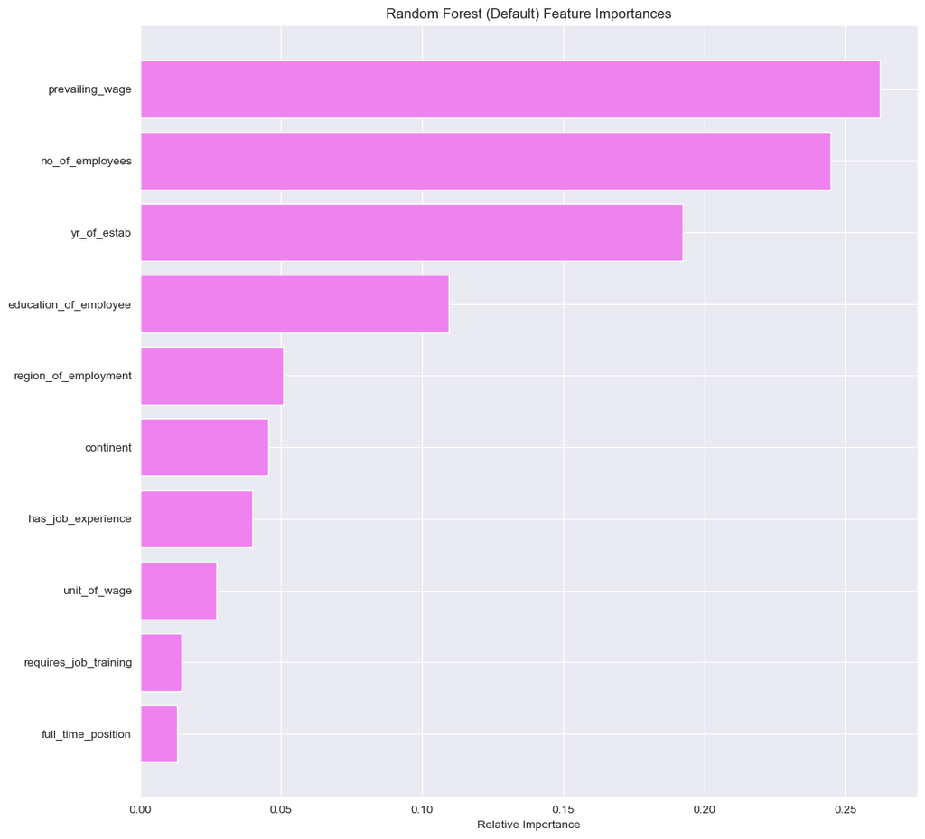

```python
# show important features
importances = rf_estimator.feature_importances_
indices = np.argsort(importances)
feature_names = list(X.columns)

plt.figure(figsize=(12,12))
plt.title('Random Forest (Default) Feature Importances')
plt.barh(range(len(indices)), importances[indices], color='violet', align='center')
plt.yticks(range(len(indices)), [feature_names[i] for i in indices])
plt.xlabel('Relative Importance')
plt.show()
```

**Observations:**

## Hypertuning

### Decision Tree

```python
# Choose the type of classifier.
dtree_tuned = DecisionTreeClassifier(random_state=1)

# Grid of parameters to choose from
parameters = {'max_depth': list(np.arange(2,10)) + [None],
              'min_samples_leaf': [1, 5, 10],
              'max_leaf_nodes' : [2, 10, 15] + [None],
              'min_impurity_decrease': [0.01, 0.1]
             }

# Type of scoring used to compare parameter combinations
scorer = metrics.make_scorer(metrics.r2_score)

# Run the grid search
grid_obj = GridSearchCV(dtree_tuned, parameters, scoring=scorer,cv=5)
grid_obj = grid_obj.fit(X_train, y_train)

# Set the clf to the best combination of parameters
dtree_tuned = grid_obj.best_estimator_

# Fit the best algorithm to the data.
dtree_tuned.fit(X_train, y_train)
```

```
DecisionTreeClassifier(max_depth=3, max_leaf_nodes=10,
                       min_impurity_decrease=0.01, random_state=1)
```

```python
#Using above defined function to get accuracy, recall and precision on train and test set
dtree_tuned_score=get_metrics_score(dtree_tuned)
```

```
Accuracy on training set :  0.7263399865440682
Accuracy on test set :  0.7350863422291993
Recall on training set :  0.3972648995441499
Recall on test set :  0.40015754233950374
Precision on training set :  0.6421943231441049
Precision on test set :  0.6693017127799736
```

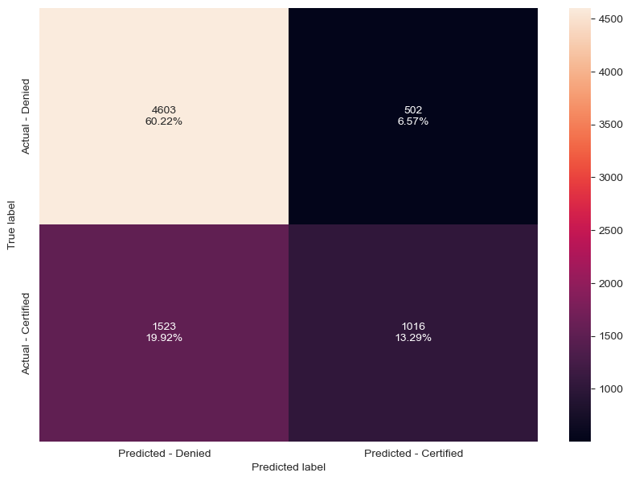

```python
# make confusion matrix
make_confusion_matrix(dtree_tuned,y_test)
```

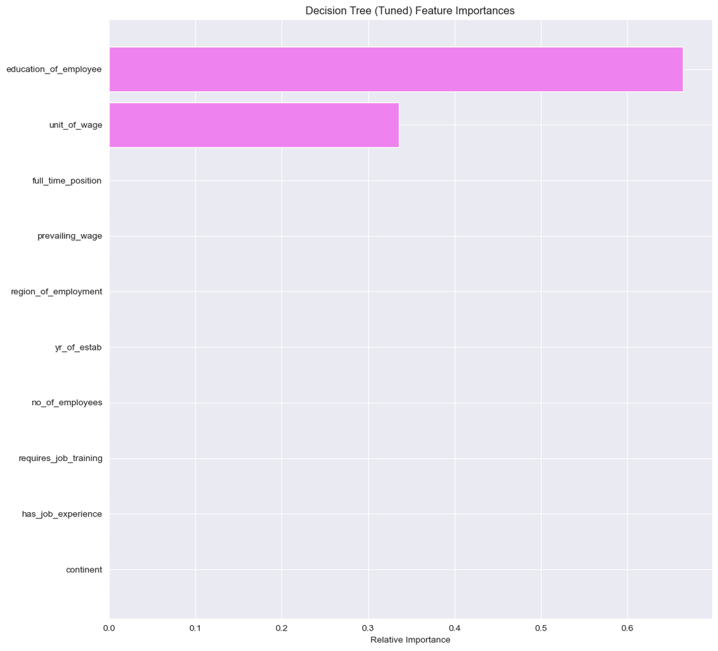

```python
# show important features
importances = dtree_tuned.feature_importances_
indices = np.argsort(importances)
feature_names = list(X.columns)

plt.figure(figsize=(12,12))
plt.title('Decision Tree (Tuned) Feature Importances')
plt.barh(range(len(indices)), importances[indices], color='violet', align='center')
plt.yticks(range(len(indices)), [feature_names[i] for i in indices])
plt.xlabel('Relative Importance')
plt.show()
```

**Observations:**

- Only two important factors: education_of_employee and unit_of_wage, respectively
- Pretty good Accuracy and Precision scores, but the Recall score is suboptimal

### Bagging Classifier

```python
# Choose the type of classifier.
bagging_estimator_tuned = BaggingClassifier(random_state=1)

# Grid of parameters to choose from
## add from article
parameters = {'max_samples': [0.7,0.9,1],
              'max_features': [0,7,0.9,1],
              'n_estimators' : [10,20,40,50],
             }

# Type of scoring used to compare parameter combinations
acc_scorer = metrics.make_scorer(metrics.recall_score)

# Run the grid search
grid_obj = GridSearchCV(bagging_estimator_tuned, parameters, scoring=acc_scorer,cv=5)
grid_obj = grid_obj.fit(X_train, y_train)

# Set the clf to the best combination of parameters
bagging_estimator_tuned = grid_obj.best_estimator_

# Fit the best algorithm to the data.
bagging_estimator_tuned.fit(X_train, y_train)
```

```
BaggingClassifier(max_features=7, max_samples=1, random_state=1)
```

```python
#Using above defined function to get accuracy, recall and precision on train and test set
bagging_estimator_tuned_score=get_metrics_score(bagging_estimator_tuned)
```

```
Accuracy on training set :  0.33208118412200044
Accuracy on test set :  0.33215593929879644
Recall on training set :  1.0
Recall on test set :  1.0
Precision on training set :  0.33208118412200044
Precision on test set :  0.33215593929879644
```

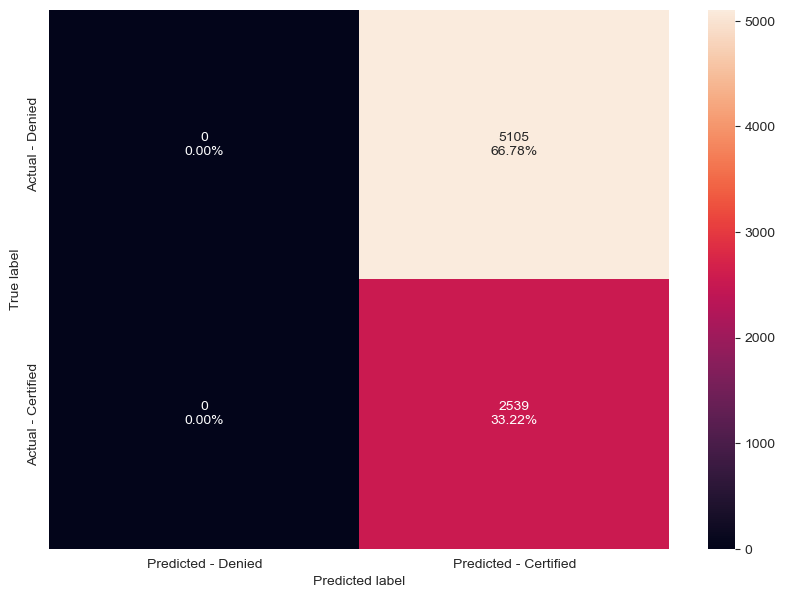

```python
# make confusion matrix
make_confusion_matrix(bagging_estimator_tuned,y_test)
```

**Observations:**

- The recall scores in both the train and test sets are both 1
- The precision and accuracy scores for both the train and test sets are each 0.33
- This model has 0 predicted Denied values and the Certified predictions are not great

### Logisitic Regression - Base Estimator

```python
bagging_lr=BaggingClassifier(base_estimator=LogisticRegression(solver='liblinear',random_state=1,max_iter=1000),random_state=1)
bagging_lr.fit(X_train,y_train)
```

```
BaggingClassifier(base_estimator=LogisticRegression(max_iter=1000,
                                                    random_state=1,
                                                    solver='liblinear'),
                  random_state=1)
```

```python
#Using above defined function to get accuracy, recall and precision on train and test set
bagging_lr_score=get_metrics_score(bagging_lr)
```

```
Accuracy on training set :  0.6679188158779995
Accuracy on test set :  0.6678440607012036
Recall on training set :  0.0
Recall on test set :  0.0
Precision on training set :  0.0
Precision on test set :  0.0
```

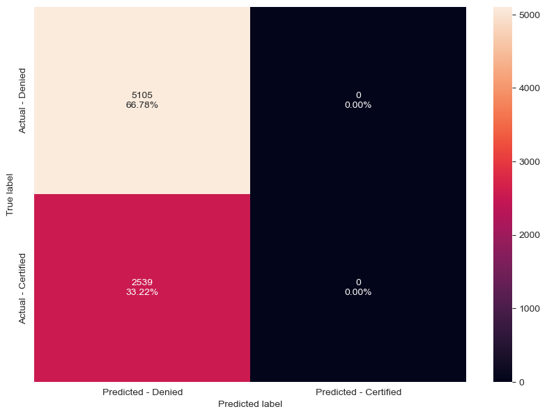

```python
# make confusion matrix
make_confusion_matrix(bagging_lr,y_test)
```

**Observations:**

### Random Forest Classifier

```python
# Choose the type of classifier.
rf_estimator_tuned = RandomForestClassifier(random_state=1)

# Grid of parameters to choose from
## add from article
parameters = {"n_estimators": [150,200,250],
    "min_samples_leaf": np.arange(5, 10),
    "max_features": np.arange(0.2, 0.3, 0.1),
    "max_samples": np.arange(0.3, 0.4, 0.1),
             }

# Type of scoring used to compare parameter combinations
acc_scorer = metrics.make_scorer(metrics.recall_score)

# Run the grid search
grid_obj = GridSearchCV(rf_estimator_tuned, parameters, scoring=acc_scorer,cv=5)
grid_obj = grid_obj.fit(X_train, y_train)

# Set the clf to the best combination of parameters
rf_estimator_tuned = grid_obj.best_estimator_

# Fit the best algorithm to the data.
rf_estimator_tuned.fit(X_train, y_train)
```

[output not shown]

```python
#Using above defined function to get accuracy, recall and precision on train and test set
rf_estimator_tuned_score=get_metrics_score(rf_estimator_tuned)
```

```
Accuracy on training set :  0.7798273155416012
Accuracy on test set :  0.7460753532182104
Recall on training set :  0.5098767516461252
Recall on test set :  0.45687278456085073
Precision on training set :  0.7467853610286844
Precision on test set :  0.6736353077816493
```

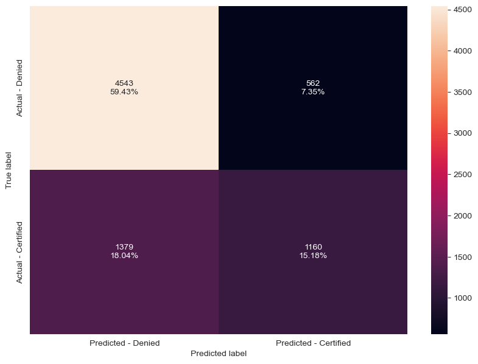

```python
# make confusion matrix
make_confusion_matrix(rf_estimator_tuned,y_test)
```

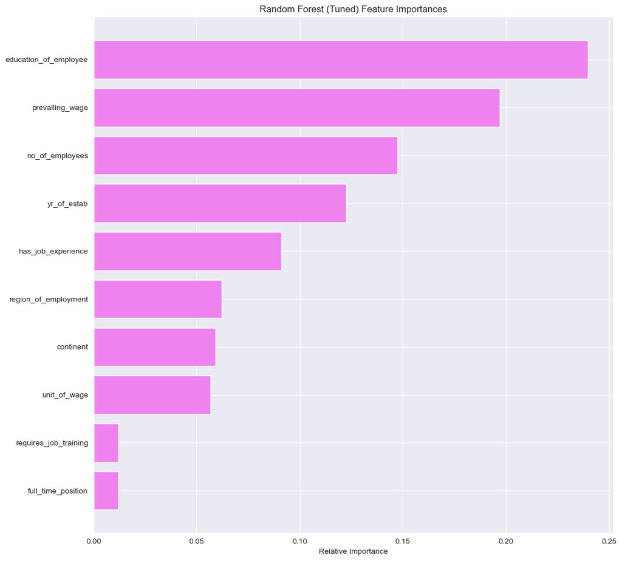

```python
# show important features
importances = rf_estimator_tuned.feature_importances_
indices = np.argsort(importances)
feature_names = list(X.columns)

plt.figure(figsize=(12,12))
plt.title('Random Forest (Tuned) Feature Importances')
plt.barh(range(len(indices)), importances[indices], color='violet', align='center')
plt.yticks(range(len(indices)), [feature_names[i] for i in indices])
plt.xlabel('Relative Importance')
plt.show()
```

**Observations:**

- All of the scores could be improved for the train and test sets, but the train and test sets have pretty similar scores and none of them are all that bad

### Random Forest- Weighted

```python
# determine shape of dataframe
df.shape
```

```
(25480, 11)
```

```python
# determine value counts for case_status
df.case_status.value_counts()
```

```
0    17018
1     8462
Name: case_status, dtype: int64
```

```python
# print the class weight values
print ('Certified(0): ', round(1- (17018/25480), 2))
print ('Denied(1): ', round(1-(8462/25480), 2))
```

```
Certified(0):  0.33
Denied(1):  0.67
```

```python
# Choose the type of classifier.
rf_estimator_weighted = RandomForestClassifier(random_state=1)

# Grid of parameters to choose from
## add from article
parameters = {
    "class_weight": [{0: 0.33, 1: 0.67}],
    "n_estimators": [100,150],
    "min_samples_leaf": np.arange(5, 10),
    "max_features": np.arange(0.2, 0.3, 0.1),
    "max_samples": np.arange(0.3, 0.4, 0.1),
}

# Type of scoring used to compare parameter combinations
acc_scorer = metrics.make_scorer(metrics.recall_score)

# Run the grid search
grid_obj = GridSearchCV(rf_estimator_weighted, parameters, scoring=acc_scorer,cv=5)
grid_obj = grid_obj.fit(X_train, y_train)

# Set the clf to the best combination of parameters
rf_estimator_weighted = grid_obj.best_estimator_

# Fit the best algorithm to the data.
rf_estimator_weighted.fit(X_train, y_train)
```

```
RandomForestClassifier(class_weight={0: 0.33, 1: 0.67}, max_features=0.2,
                       max_samples=0.3, min_samples_leaf=9, random_state=1)
```

```python
#Using above defined function to get accuracy, recall and precision on train and test set
rf_estimator_weighted_score=get_metrics_score(rf_estimator_weighted)
```

```
Accuracy on training set :  0.7474209464005382
Accuracy on test set :  0.7305075876504448
Recall on training set :  0.6809049468174911
Recall on test set :  0.6474990153603781
Precision on training set :  0.6066486161251504
Precision on test set :  0.5852616589533642
```

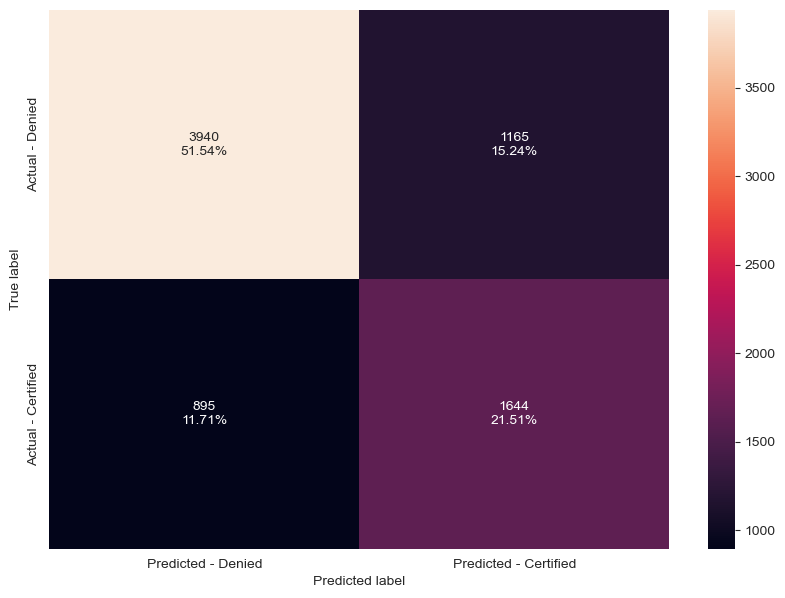

```python
# make confusion matrix
make_confusion_matrix(rf_estimator_weighted,y_test)
```

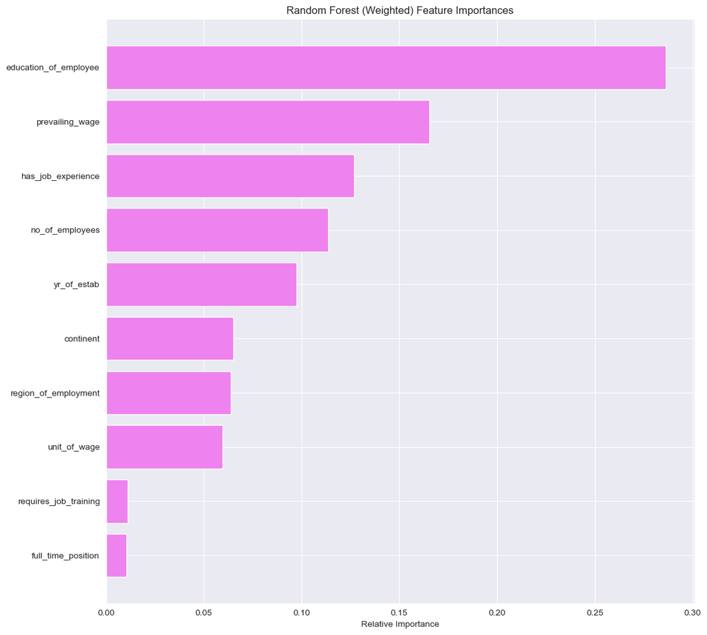

```python
# show important features
importances = rf_estimator_weighted.feature_importances_
indices = np.argsort(importances)
feature_names = list(X.columns)

plt.figure(figsize=(12,12))
plt.title('Random Forest (Weighted) Feature Importances')
plt.barh(range(len(indices)), importances[indices], color='violet', align='center')
plt.yticks(range(len(indices)), [feature_names[i] for i in indices])
plt.xlabel('Relative Importance')
plt.show()
```

**Observations:**

- Similar to the Random Forest Classifier model, this model has decent scores all around and has values that are similar between the train and test sets
- education_of_employee seems to have the highest importance out of the listed variables

### Comparing all models till now

```python
# defining list of models
models = [dtree, dtree_tuned, bagging_estimator,bagging_estimator_tuned,bagging_lr,rf_estimator,rf_estimator_tuned,
          rf_estimator_weighted]

# defining empty lists to add train and test results
acc_train = []
acc_test = []
recall_train = []
recall_test = []
precision_train = []
precision_test = []

# looping through all the models to get the accuracy, precall and precision scores
for model in models:
    j = get_metrics_score(model,False)
    acc_train.append(np.round(j[0],2))
    acc_test.append(np.round(j[1],2))
    recall_train.append(np.round(j[2],2))
    recall_test.append(np.round(j[3],2))
    precision_train.append(np.round(j[4],2))
    precision_test.append(np.round(j[5],2))
```

```python
# create new dataframe
comparison_frame = pd.DataFrame({'Model':['Decision Tree with default parameters', 'Tuned Decision Tree','Bagging classifier with default parameters','Tuned Bagging Classifier',
                                        'Bagging classifier with base_estimator=LR', 'Random Forest with default parameters',
                                         'Tuned Random Forest Classifier','Random Forest with class_weights'],
                                          'Train_Accuracy': acc_train,'Test_Accuracy': acc_test,
                                          'Train_Recall':recall_train,'Test_Recall':recall_test,
                                          'Train_Precision':precision_train,'Test_Precision':precision_test})
BaggingFrame = comparison_frame
BaggingFrame
```

|  | Model | Train_Accuracy | Test_Accuracy | Train_Recall | Test_Recall | Train_Precision | Test_Precision |
| --- | --- | --- | --- | --- | --- | --- | --- |
| 0 | Decision Tree with default parameters | 1.00 | 0.66 | 1.00 | 0.50 | 1.00 | 0.49 |
| 1 | Tuned Decision Tree | 0.73 | 0.74 | 0.40 | 0.40 | 0.64 | 0.67 |
| 2 | Bagging classifier with default parameters | 0.98 | 0.72 | 0.95 | 0.45 | 0.99 | 0.60 |
| 3 | Tuned Bagging Classifier | 0.33 | 0.33 | 1.00 | 1.00 | 0.33 | 0.33 |
| 4 | Bagging classifier with base_estimator=LR | 0.67 | 0.67 | 0.00 | 0.00 | 0.00 | 0.00 |
| 5 | Random Forest with default parameters | 1.00 | 0.74 | 1.00 | 0.49 | 1.00 | 0.63 |
| 6 | Tuned Random Forest Classifier | 0.78 | 0.75 | 0.51 | 0.46 | 0.75 | 0.67 |
| 7 | Random Forest with class_weights | 0.75 | 0.73 | 0.68 | 0.65 | 0.61 | 0.59 |

**Observations:**

- As was mentioned above, the two models that seemed to have performed the best were the Tuned Random Forest Classifier and the Random Forest with class_weights.
- Between those two models, they had very similar accuracies, Random Forest with class_weights had higher recall scores, and Tuned Random Forest Classifier had higher precision scores

## Boosting

### ADABoost Classifier

```python
abc = AdaBoostClassifier(random_state=1)
abc.fit(X_train,y_train)
```

```
AdaBoostClassifier(random_state=1)
```

```python
#Using above defined function to get accuracy, recall and precision on train and test set
abc_score=get_metrics_score(abc)
```

```
Accuracy on training set :  0.7360955371159453
Accuracy on test set :  0.7340397697540555
Recall on training set :  0.4273172378862063
Recall on test set :  0.41788105553367466
Precision on training set :  0.6580863234529382
Precision on test set :  0.656559405940594
```

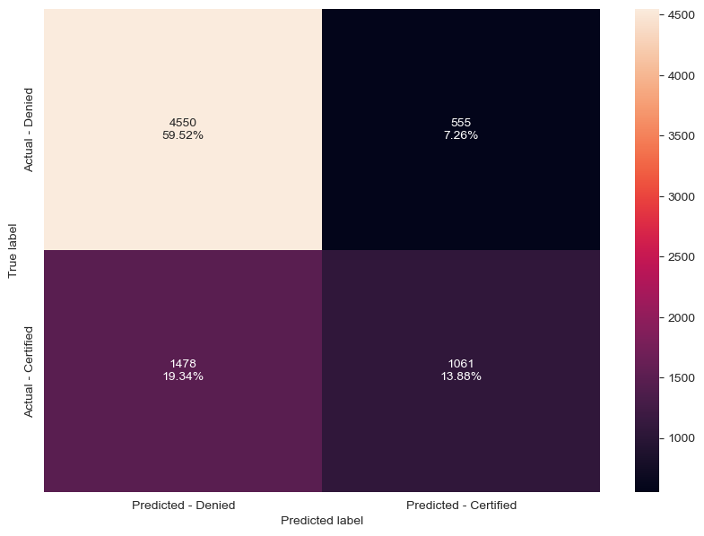

```python
make_confusion_matrix(abc,y_test)
```

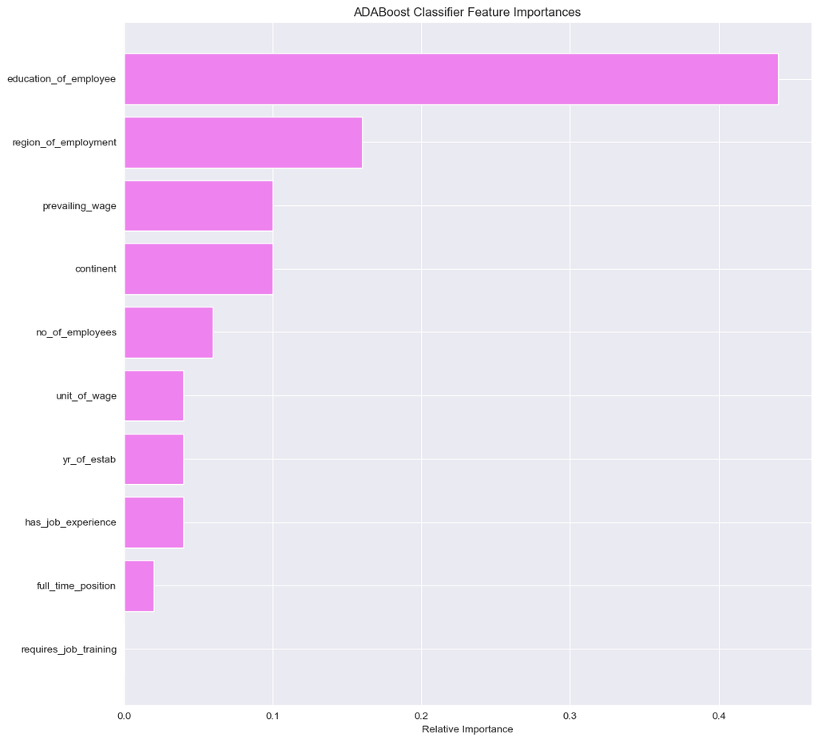

```python
importances = abc.feature_importances_
indices = np.argsort(importances)
feature_names = list(X.columns)

plt.figure(figsize=(12,12))
plt.title('ADABoost Classifier Feature Importances')
plt.barh(range(len(indices)), importances[indices], color='violet', align='center')
plt.yticks(range(len(indices)), [feature_names[i] for i in indices])
plt.xlabel('Relative Importance')
plt.show()
```

### Gradient Boosting Classifier

```python
gbc = GradientBoostingClassifier(random_state=1)
gbc.fit(X_train,y_train)
```

```
GradientBoostingClassifier(random_state=1)
```

```python
#Using above defined function to get accuracy, recall and precision on train and test set
gbc_score=get_metrics_score(gbc)
```

```
Accuracy on training set :  0.7545413769903566
Accuracy on test set :  0.7517006802721088
Recall on training set :  0.5037987506331251
Recall on test set :  0.49625836943678614
Precision on training set :  0.6746552113949807
Precision on test set :  0.6705694518360831
```

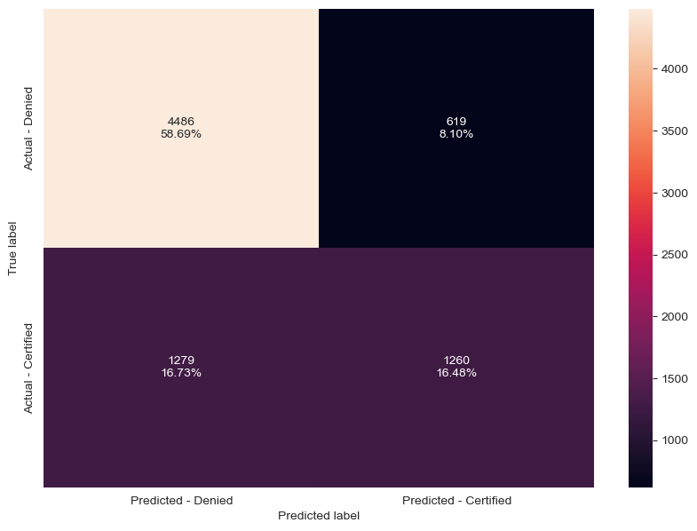

```python
make_confusion_matrix(gbc,y_test)
```

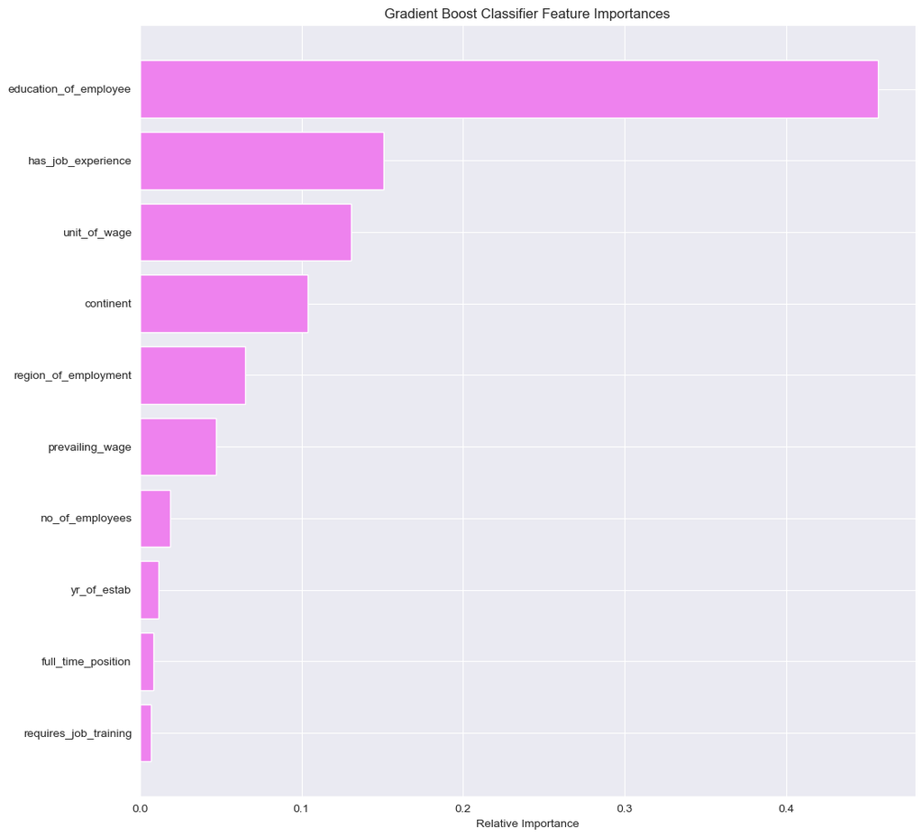

```python
importances = gbc.feature_importances_
indices = np.argsort(importances)
feature_names = list(X.columns)

plt.figure(figsize=(12,12))
plt.title('Gradient Boost Classifier Feature Importances')
plt.barh(range(len(indices)), importances[indices], color='violet', align='center')
plt.yticks(range(len(indices)), [feature_names[i] for i in indices])
plt.xlabel('Relative Importance')
plt.show()
```

### XGBoost Classifier

```python
xgb = XGBClassifier(random_state=1,eval_metric='logloss')#, enable_categorical = True)
xgb.fit(X_train,y_train)
```

```
XGBClassifier(base_score=None, booster=None, callbacks=None,
              colsample_bylevel=None, colsample_bynode=None,
              colsample_bytree=None, early_stopping_rounds=None,
              enable_categorical=False, eval_metric='logloss',
              feature_types=None, gamma=None, gpu_id=None, grow_policy=None,
              importance_type=None, interaction_constraints=None,
              learning_rate=None, max_bin=None, max_cat_threshold=None,
              max_cat_to_onehot=None, max_delta_step=None, max_depth=None,
              max_leaves=None, min_child_weight=None, missing=nan,
              monotone_constraints=None, n_estimators=100, n_jobs=None,
              num_parallel_tree=None, predictor=None, random_state=1, ...)
```

```python
#Using above defined function to get accuracy, recall and precision on train and test set
xgb_score=get_metrics_score(xgb)
```

```
Accuracy on training set :  0.836846826642745
Accuracy on test set :  0.7370486656200942
Recall on training set :  0.6439304406550734
Recall on test set :  0.4840488381252462
Precision on training set :  0.8264355362946912
Precision on test set :  0.6371176775531363
```

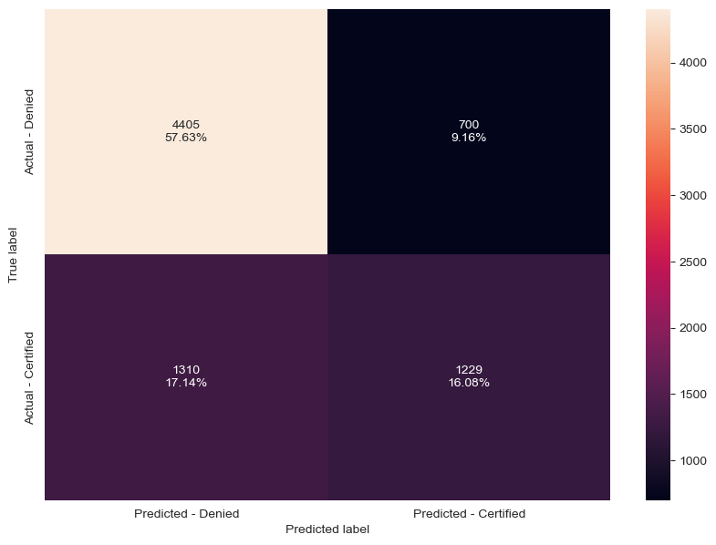

```python
make_confusion_matrix(xgb,y_test)
```

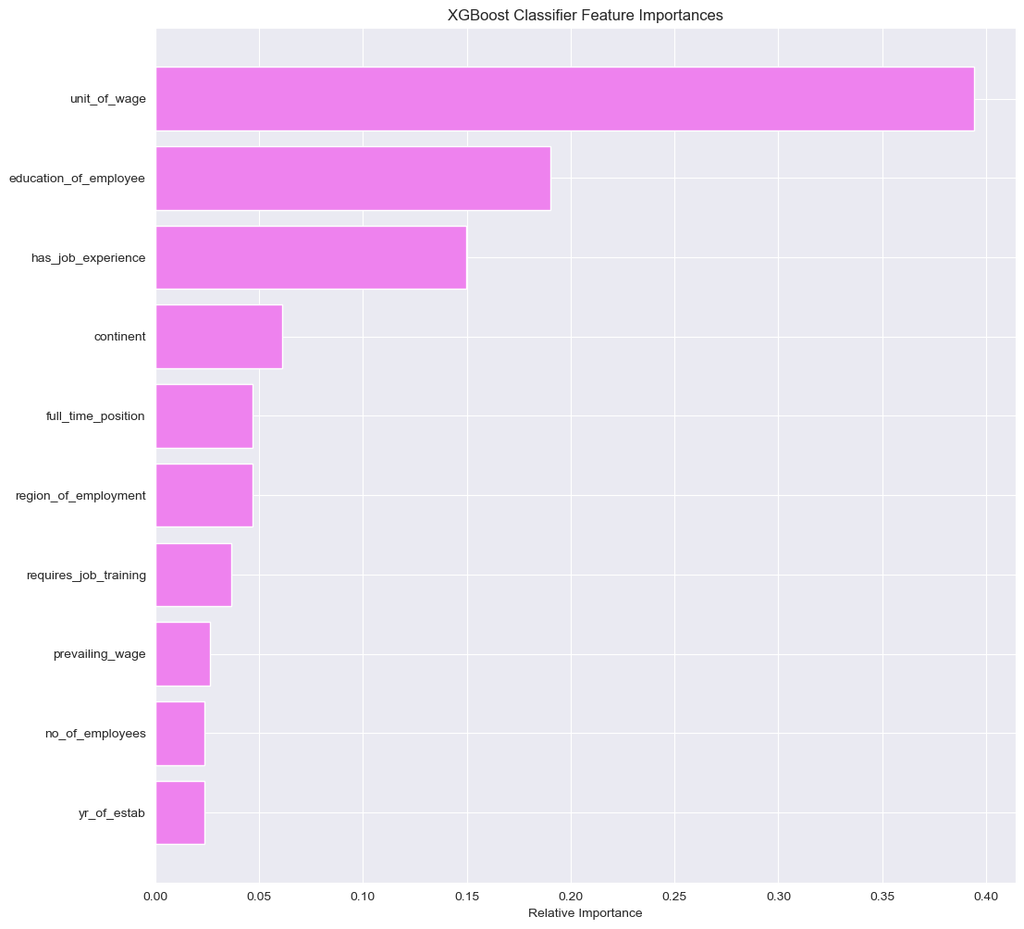

```python
importances = xgb.feature_importances_
indices = np.argsort(importances)
feature_names = list(X.columns)

plt.figure(figsize=(12,12))
plt.title('XGBoost Classifier Feature Importances')
plt.barh(range(len(indices)), importances[indices], color='violet', align='center')
plt.yticks(range(len(indices)), [feature_names[i] for i in indices])
plt.xlabel('Relative Importance')
plt.show()
```

**Observations:**

- The XGBoost Classifier slightly overfit the train data set
- All models had similar accuracy scores, with Gradient Boost Classifier having the highest
- All models had similarly low recall scores. XGBoost had the highest train recall score, but the test recall score was much lower
- All models had similar precision scores. XGBoost had the highest train precision score, but the test precision score was closer to the other model's precision scores

## Hyperparameter Tuning

### ADABoost Classifier

```python
# Choose the type of classifier.
abc_tuned = AdaBoostClassifier(random_state=1)

# Grid of parameters to choose from
## add from article
parameters = {
    #Let's try different max_depth for base_estimator
    "base_estimator":[DecisionTreeClassifier(max_depth=1, random_state=1),DecisionTreeClassifier(max_depth=2, random_state=1),DecisionTreeClassifier(max_depth=3, random_state=1)],
    "n_estimators": np.arange(10,50,10),
    "learning_rate":np.arange(0.1,1.2,0.4)
}

# Type of scoring used to compare parameter combinations
acc_scorer = metrics.make_scorer(metrics.recall_score)

# Run the grid search
grid_obj = GridSearchCV(abc_tuned, parameters, scoring=acc_scorer,cv=5)
grid_obj = grid_obj.fit(X_train, y_train)

# Set the clf to the best combination of parameters
abc_tuned = grid_obj.best_estimator_

# Fit the best algorithm to the data.
abc_tuned.fit(X_train, y_train)
```

```
AdaBoostClassifier(base_estimator=DecisionTreeClassifier(max_depth=3,
                                                         random_state=1),
                   learning_rate=0.5, n_estimators=20, random_state=1)
```

```python
#Using above defined function to get accuracy, recall and precision on train and test set
abc_tuned_score=get_metrics_score(abc_tuned)
```

```
Accuracy on training set :  0.75112132765194
Accuracy on test set :  0.7481684981684982
Recall on training set :  0.5053182508863752
Recall on test set :  0.4982276486805829
Precision on training set :  0.6648156374944469
Precision on test set :  0.6602296450939458
```

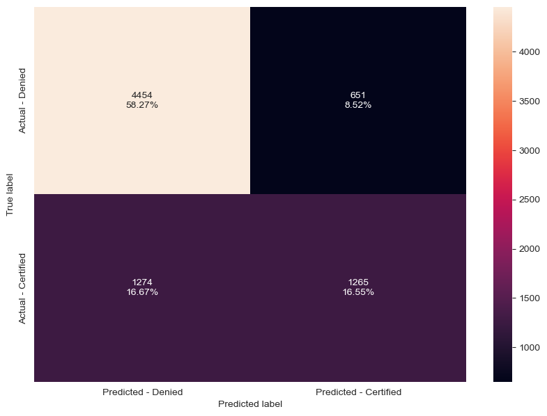

```python
make_confusion_matrix(abc_tuned,y_test)
```

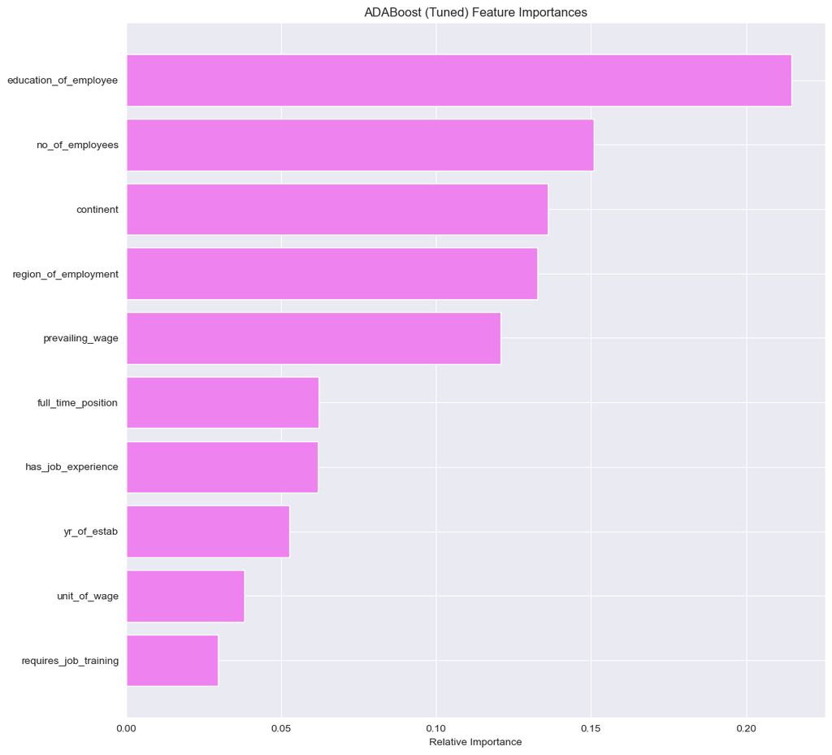

```python
importances = abc_tuned.feature_importances_
indices = np.argsort(importances)
feature_names = list(X.columns)

plt.figure(figsize=(12,12))
plt.title('ADABoost (Tuned) Feature Importances')
plt.barh(range(len(indices)), importances[indices], color='violet', align='center')
plt.yticks(range(len(indices)), [feature_names[i] for i in indices])
plt.xlabel('Relative Importance')
plt.show()
```

**Observations:**

- This model does not overfit and has pretty good accuracy and precision scores. Recall score is pretty low.
- education_of_employee is the most important factor